# R Notebook

# Libraries

```r
library(tidyr)
```

#Richness, PD, MPD should change to referencing dat6 (it is the same data I just added the MPD data to the dat4 dataframe)

```r
options(contrasts=c("contr.helmert","contr.poly"))
options(contrasts=c("contr.treatment","contr.poly"))
options("contrasts")
```

# Calculating richness by plant community

```r
dat6DM<-dat6%>%
  filter(Community.x=="DM")%>%
  dplyr::select(OTU0:OTU9)
length(which(colSums(dat6DM)>0)) # 18 taxa in DM

dat6MM<-dat6%>%
  filter(Community.x=="MM")%>%
  dplyr::select(OTU0:OTU9)
length(which(colSums(dat6MM)>0)) # 18 taxa in MM

dat6FF<-dat6%>%
  filter(Community.x=="FF")%>%
  dplyr::select(OTU0:OTU9)
length(which(colSums(dat6FF)>0)) # 15 taxa in FF

dat6SB<-dat6%>%
  filter(Community.x=="SB")%>%
  dplyr::select(OTU0:OTU9)
length(which(colSums(dat6SB)>0)) # 13 taxa in SB

#abundance
rowSums(dat6[,9:43])
```

## Richness

```r
richnessmean<-dat6%>%
  group_by(Community.x,Site)%>%
  summarise(mean=mean(SR),se=std.error(SR),count=n())
```

##Stats

gls <- fit linear model using generalized least squares

lme <- linear mixed-effects models

|  | numDF | denDF | F-value | p-value |
| --- | --- | --- | --- | --- |
| (Intercept) | 1 | 34 | 76.64922 | <.0001 |
| Community.x | 3 | 34 | 2.90119 | 0.0490 |
| Site | 1 | 34 | 4.30747 | 0.0456 |

# Faiths Phylogenetic distance

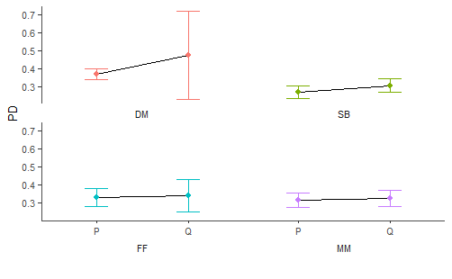

## Stats

```r
m1<-gls(PD~Community.x+Site,data=dat6,na.action=na.omit)
#m1<-gls(mpd.obs.z.weighted~Site,data=dat6,na.action=na.omit)
anova(m1,type="marginal")
```

[output not shown]

# MPD

an MPD that is > 0 is overdispersion, and MPD < 0 is phylogenetic clustering mpd.obs.z is what we want it compares the observed to the randomized data, if > 0 overdispersion, if < 0 clustered

```r
#with year
mpdmean<-dat6%>%
  group_by(Site,Community.x,PlantIndividual)%>%
  filter(is.na(mpd.obs.z.weighted)==F)%>%
  summarise(mean=mean(mpd.obs.z.weighted,na.rm=T),se=std.error(mpd.obs.z.weighted),n=n())%>%
  ungroup()
```

```
You can override using the `.groups` argument.
```

## Stats

```r
# m1<-gls(mpd.obs.z.weighted~HostPlant+Site,data=dat6,na.action=na.omit)
# anova(m1,type="marginal")

# m2<-gls(mpd.obs.z.weighted~HostPlant*Site,data=phragspartina,na.action=na.omit)
# anova(m2,type="marginal")

m1<-lme(mpd.obs.z.weighted~Community.x+Site,random=~1|PlantIndividual,data=dat6,na.action=na.omit)
# m2<-lme(mpd.obs.z.weighted~HostPlant+Site,random=~1|Year,weights=varIdent(form=~1|Site),data=dat6,na.action=na.omit)
# m3<-lme(mpd.obs.z.weighted~HostPlant+Site,random=~1|Year,weights=varIdent(form=~1|HostPlant),data=dat6,na.action=na.omit)
# m4<-lme(mpd.obs.z.weighted~HostPlant+Site,random=~1|Year,weights=varIdent(form=~1|HostPlantSite),data=dat6,na.action=na.omit)
# anova(m1,m2,m3,m4)
anova(m1,type="marginal")
hist(resid(m1))
plot(fitted(m1),resid(m1))


#remove the space in HostPlantSite and make it a factor
#dat6$HostPlantSite<-gsub("\\s+", "", dat6$HostPlantSite)
#dat6$HostPlantSite<-factor(dat6$HostPlantSite)

m2<-lme(mpd.obs.z.weighted~HostPlantSite,random=~1|Year,data=dat6,na.action=na.omit)#,weights=varIdent(form=~1|HostPlantSite)
m2<-gls(mpd.obs.z.weighted~HostPlantSite,data=dat6,na.action=na.omit)#,weights=varIdent(form=~1|HostPlantSite)

#this does not work, it gives the wrong means
#summary(glht(m2, linfct = mcp(HostPlantSite=c("Phragmitesaustralis_TurtleCove=0","Sagittarialancifolia_TurtleCove=0","Spartinapatens_TurtleCove=0","Phragmitesaustralis_CERF=0","Spartinaalterniflora_CERF=0","Spartinapatens_CERF=0","Juncusroemerianus_LUMCON=0","Phragmitesaustralis_LUMCON=0","Spartinaalterniflora_LUMCON=0","Spartinapatens_LUMCON=0"))))

m2em<-as.data.frame(summary(emmeans(m2,~HostPlantSite)))
m2.r<-ref_grid(m2)
m2.s<-emmeans(m2.r,"HostPlantSite")
test(m2.s,adjust="fdr")#dunnett (what glht uses) or fdr


m2<-lme(mpd.obs.z.weighted~HostPlant*Site,random=~1|Year,data=phragspartina,na.action=na.omit)
anova(m2,type="marginal")

#tyring heterogeneou variances, not significant
#m2a<-lme(mpd.obs.z.weighted~HostPlant*Site,random=~1|Year,weights=varIdent(form=~1|HostPlant*Site),data=phragspartina,na.action=na.omit)
#anova(m2,m2a)

# m2<-lme(mpd.obs.z.weighted~Site,random=~1|HostPlant,data=dat6,na.action=na.omit)
# anova(m2)
```

# Plot for mdp and richness together

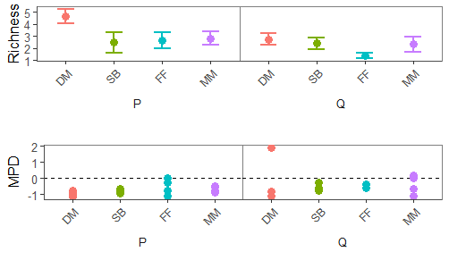

## MPD trials

below are the trials that I did for individual (abundance weighted vs not and grouped by species x site, site, and species)

MPD by plant individual notes on results of unweighted vs weighted. the overall pattern is very similar, but the weighted results tend to have slightly smaller error bars so that some (junroe) might be significantly positive. However, it probably makes the most sense to use unweighted because (based on the labeling file in google drive) it sounds like they only isolated one “morphotype” per plate (of 5 root pieces) therefore it is unlikely to get an abundance >2 (there were two plates of 5 roots each for each sample).

```r
mpdmean<-ses.mpd.result.ind.abun%>%
  full_join(dat4)%>%
  group_by(Site,Community.x)%>%
  filter(is.na(mpd.obs.z)==F)%>%
  summarise(mean=mean(mpd.obs.z,na.rm=T),se=std.error(mpd.obs.z),n=n())%>%
  ungroup()
mpdmean
```

| Site | Community.x | mean | se | n |
| --- | --- | --- | --- | --- |
| P | DM | -0.9668446 | 0.06525118 | 6 |
| P | SB | -0.8046030 | 0.09531601 | 3 |
| P | FF | -0.5035201 | 0.23223450 | 4 |
| P | MM | -0.7128896 | 0.06363908 | 6 |
| Q | DM | -0.1792593 | 0.74641941 | 4 |
| Q | SB | -0.6097818 | 0.11547353 | 4 |
| Q | FF | -0.4768022 | 0.07291528 | 2 |
| Q | MM | -0.4093816 | 0.30701683 | 4 |

## Stats

```r
dm1<-gls(mpd.obs.z~HostPlant+Site,data=dat6,na.action=na.omit)
m1<-gls(mpd.obs.z~Site,data=dat6,na.action=na.omit)
anova(m1)

m2<-lme(mpd.obs.z~Site,random=~1|HostPlant,data=dat6,na.action=na.omit)
anova(m2)
```

[output not shown]

# Tree plotting

```r
# par(mfrow=c(2,2))
# for (i in names(traits)) {
#   plot(phy, show.tip.label=FALSE, main=i)
#   tiplabels(pch=22, col=traits[,i]+1, bg=traits[,i]+1, cex=1.5)
# }

dat.comm.sum.DMt<-as.data.frame(t(dat.comm.sum.DM))
dat.comm.sumt<-as.data.frame(t(dat.comm.sum))

plot(trimmednwk, show.tip.label=FALSE)
colort<-ifelse(dat.comm.sumt$DM >0,2,1)
tiplabels(pch=22, col=colort, bg=colort, cex=1.5)

plot(trimmednwk, show.tip.label=T)
```

# Tree with matrix

```r
matrix2 <- apply(matrix,trimws)
```

```
Error in apply(matrix, trimws) :
  argument "FUN" is missing, with no default
```